# Reproducible Research: Peer Assessment 1

## Loading and preprocessing the data

Loading the Data

```r
activity_data <- read.csv("activity.csv", header=TRUE)

str(activity_data)
```

```
## 'data.frame':    17568 obs. of  3 variables:
##  $ steps   : int  NA NA NA NA NA NA NA NA NA NA ...
##  $ date    : chr  "2012-10-01" "2012-10-01" "2012-10-01" "2012-10-01" ...
##  $ interval: int  0 5 10 15 20 25 30 35 40 45 ...
```

Load Library “dplyr” Convert the “Date” column from a character to date data type

```r
library(dplyr)
activity_data <- activity_data %>% mutate(date = as.Date(date,"%Y-%m-%d"))

str(activity_data)
```

```
## 'data.frame':    17568 obs. of  3 variables:
##  $ steps   : int  NA NA NA NA NA NA NA NA NA NA ...
##  $ date    : Date, format: "2012-10-01" "2012-10-01" ...
##  $ interval: int  0 5 10 15 20 25 30 35 40 45 ...
```

## What is mean total number of steps taken per day?

### Calculate the total number of steps taken per day

```r
steps_per_day <- aggregate(activity_data$steps, by = list(date = activity_data$date), FUN = sum, na.rm = TRUE)
names(steps_per_day) <- c("date", "steps")
print(steps_per_day)
```

```
##          date steps
## 1  2012-10-01     0
## 2  2012-10-02   126
## 3  2012-10-03 11352
## 4  2012-10-04 12116
## 5  2012-10-05 13294
## 6  2012-10-06 15420
## 7  2012-10-07 11015
## 8  2012-10-08     0
## 9  2012-10-09 12811
## 10 2012-10-10  9900
## 11 2012-10-11 10304
## 12 2012-10-12 17382
## 13 2012-10-13 12426
## 14 2012-10-14 15098
```

[output cut: 47 more lines]

### Make a histogram of the total number of steps taken each day

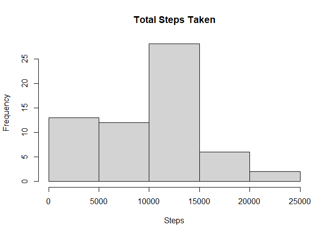

```r
hist(steps_per_day$steps, xlab = "Steps", ylab = "Frequency", main = "Total Steps Taken")
```

### Calculate and report the mean and median of the total number of steps taken per day

```r
steps_per_day_2 <- activity_data %>% group_by(date) %>% summarise(sum = sum(steps, na.rm = TRUE), mean = mean(steps, na.rm = TRUE), median = median(steps, na.rm = TRUE))
print(steps_per_day_2)
```

```
## # A tibble: 61 x 4
##    date         sum    mean median
##    <date>     <int>   <dbl>  <dbl>
##  1 2012-10-01     0 NaN         NA
##  2 2012-10-02   126   0.438      0
##  3 2012-10-03 11352  39.4        0
##  4 2012-10-04 12116  42.1        0
##  5 2012-10-05 13294  46.2        0
##  6 2012-10-06 15420  53.5        0
##  7 2012-10-07 11015  38.2        0
##  8 2012-10-08     0 NaN         NA
##  9 2012-10-09 12811  44.5        0
## 10 2012-10-10  9900  34.4        0
## # ... with 51 more rows
```

## What is the average daily activity pattern?

### Make a time series plot (i.e. type = “l”) of the 5-minute interval (x-axis) and the average number of steps taken, averaged across all days (y-axis)

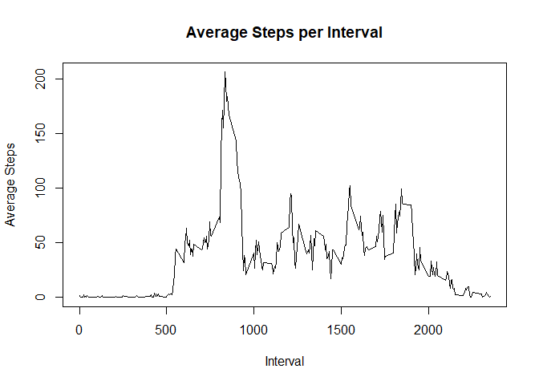

```r
steps_per_interval <- aggregate(activity_data$steps, by = list(interval = activity_data$interval), FUN = mean, na.rm = TRUE)
names(steps_per_interval) <- c("interval", "steps")
plot(steps_per_interval$interval, steps_per_interval$steps, type = "l", main = "Average Steps per Interval", ylab = "Average Steps", xlab = "Interval")
```

```r
steps_per_interval_max <- aggregate(activity_data$steps, by = list(interval = activity_data$interval), FUN = max, na.rm = TRUE)

names(steps_per_interval_max) <- c("interval", "steps")

steps_per_interval_max[steps_per_interval_max$steps == max(steps_per_interval_max$steps),]
```

```
##    interval steps
## 76      615   806
```

## Imputing missing values

### Calculate and report the total number of missing values in the dataset (i.e. the total number of rows with NAs)

```r
print(summary(activity_data))
```

```
##      steps             date               interval
##  Min.   :  0.00   Min.   :2012-10-01   Min.   :   0.0
##  1st Qu.:  0.00   1st Qu.:2012-10-16   1st Qu.: 588.8
##  Median :  0.00   Median :2012-10-31   Median :1177.5
##  Mean   : 37.38   Mean   :2012-10-31   Mean   :1177.5
##  3rd Qu.: 12.00   3rd Qu.:2012-11-15   3rd Qu.:1766.2
##  Max.   :806.00   Max.   :2012-11-30   Max.   :2355.0
##  NA's   :2304
```

```r
print("Total Rows with NAs is 2,304 from the column Steps")
```

```
## [1] "Total Rows with NAs is 2,304 from the column Steps"
```

### Devise a strategy for filling in all of the missing values in the dataset. The strategy does not need to be sophisticated. For example, you could use the mean/median for that day, or the mean for that 5-minute interval, etc.

```r
print("Will use mean for that interval for imputing")
```

```
## [1] "Will use mean for that interval for imputing"
```

```r
print(steps_per_interval)
```

```
##     interval       steps
## 1          0   1.7169811
## 2          5   0.3396226
## 3         10   0.1320755
## 4         15   0.1509434
## 5         20   0.0754717
## 6         25   2.0943396
## 7         30   0.5283019
## 8         35   0.8679245
## 9         40   0.0000000
## 10        45   1.4716981
## 11        50   0.3018868
## 12        55   0.1320755
## 13       100   0.3207547
## 14       105   0.6792453
```

[output cut: 274 more lines]

### Create a new dataset that is equal to the original dataset but with the missing data filled in.

```r
activity_data_1 <- merge(activity_data, steps_per_interval, by.x = "interval", by.y = "interval")
names(activity_data_1) <- c("interval", "step_x", "date", "step_y")
activity_data_1$step_x <- ifelse(is.na(activity_data_1$step_x), activity_data_1$step_y, activity_data_1$step_x)

activity_data_new <- activity_data_1[,c("interval", "step_x", "date")]
names(activity_data_new) <- c("interval", "steps", "date")

summary(activity_data_new)
```

```
##     interval          steps             date
##  Min.   :   0.0   Min.   :  0.00   Min.   :2012-10-01
##  1st Qu.: 588.8   1st Qu.:  0.00   1st Qu.:2012-10-16
##  Median :1177.5   Median :  0.00   Median :2012-10-31
##  Mean   :1177.5   Mean   : 37.38   Mean   :2012-10-31
##  3rd Qu.:1766.2   3rd Qu.: 27.00   3rd Qu.:2012-11-15
##  Max.   :2355.0   Max.   :806.00   Max.   :2012-11-30
```

### Make a histogram of the total number of steps taken each day and Calculate and report the mean and median total number of steps taken per day. Do these values differ from the estimates from the first part of the assignment? What is the impact of imputing missing data on the estimates of the total daily number of steps?

```r
steps_per_day_new <- activity_data_new %>% group_by(date) %>% summarise(sum = sum(steps, na.rm = TRUE), mean = mean(steps, na.rm = TRUE), median = median(steps, na.rm = TRUE))
```

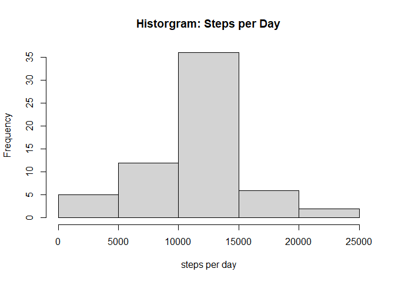

```r
hist(steps_per_day_new$sum, xlab = "steps per day", main = "Historgram: Steps per Day")
```

```r
print(steps_per_day_new)
```

```
## # A tibble: 61 x 4
##    date          sum   mean median
##    <date>      <dbl>  <dbl>  <dbl>
##  1 2012-10-01 10766. 37.4     34.1
##  2 2012-10-02   126   0.438    0
##  3 2012-10-03 11352  39.4      0
##  4 2012-10-04 12116  42.1      0
##  5 2012-10-05 13294  46.2      0
##  6 2012-10-06 15420  53.5      0
##  7 2012-10-07 11015  38.2      0
##  8 2012-10-08 10766. 37.4     34.1
##  9 2012-10-09 12811  44.5      0
## 10 2012-10-10  9900  34.4      0
## # ... with 51 more rows
```

```r
print("Differences:")
```

```
## [1] "Differences:"
```

```r
steps_per_day_new[,c(2,3,4)] - steps_per_day_2[,c(2,3,4)]
```

```
##         sum mean median
## 1  10766.19  NaN     NA
## 2      0.00    0      0
## 3      0.00    0      0
## 4      0.00    0      0
## 5      0.00    0      0
## 6      0.00    0      0
## 7      0.00    0      0
## 8  10766.19  NaN     NA
## 9      0.00    0      0
## 10     0.00    0      0
## 11     0.00    0      0
## 12     0.00    0      0
## 13     0.00    0      0
## 14     0.00    0      0
```

[output cut: 47 more lines]

## Are there differences in activity patterns between weekdays and weekends?

### Create a new factor variable in the dataset with two levels – “weekday” and “weekend” indicating whether a given date is a weekday or weekend day.

```r
activity_data_new$day <- factor(ifelse(weekdays(activity_data_new$date) %in% c("Saturday", "Sunday"), "Weekend", "Weekday"))

head(activity_data_new)
```

```
##   interval    steps       date     day
## 1        0 1.716981 2012-10-01 Weekday
## 2        0 0.000000 2012-11-23 Weekday
## 3        0 0.000000 2012-10-28 Weekend
## 4        0 0.000000 2012-11-06 Weekday
## 5        0 0.000000 2012-11-24 Weekend
## 6        0 0.000000 2012-11-15 Weekday
```

### Make a panel plot containing a time series plot (i.e. type = “l”) of the 5-minute interval (x-axis) and the average number of steps taken, averaged across all weekday days or weekend days (y-axis). See the README file in the GitHub repository to see an example of what this plot should look like using simulated data.

```r
steps_per_day_interval_day <- activity_data_new %>% group_by(interval, day) %>% summarise(sum = sum(steps, na.rm = TRUE), mean = mean(steps, na.rm = TRUE), median = median(steps, na.rm = TRUE))
```

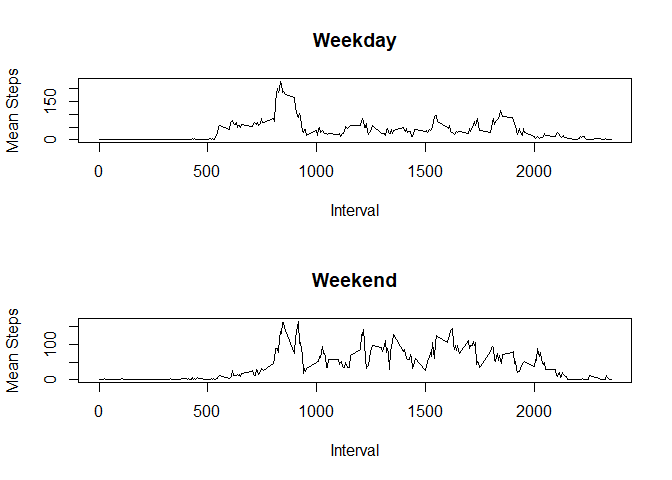

```r
steps_per_day_interval_day_wd <- steps_per_day_interval_day[steps_per_day_interval_day$day == "Weekday",]
steps_per_day_interval_day_we <- steps_per_day_interval_day[steps_per_day_interval_day$day == "Weekend",]

par(mfrow= c(2,1))
plot(steps_per_day_interval_day_wd$interval, steps_per_day_interval_day_wd$mean, type = "l",
     main = "Weekday", xlab = "Interval", ylab = "Mean Steps")
plot(steps_per_day_interval_day_we$interval, steps_per_day_interval_day_we$mean, type = "l",
     main = "Weekend", xlab = "Interval", ylab = "Mean Steps")
```